# Descriptive statistics. Measures of central tendency. Confidence intervals. P-value. T-test

### Variable types in statistics

- numeric
- interval (e.g. speed, time (MRT-mean reaction time in experiments), weight, age, sound frequency (F1, F2 in phonetics)) – any number of data points in a given interval
- natural numbers (e.g. number of occurrences in a corpus; number of authors who use this word; also age)
- scalar (e.g. Likkert scale: assess the phrase on a scale from 1… to 7) — we know the order but do not know the distance
- nominal/categorical (e.g. grammatical categories of the verb; gender; place of birth; genre)

### Measures of central tendency

- (arithmetic) mean
- median
- quartiles
- mode

```r
# Basic R:
mydata <- c(1,2,4,4,4,5,8,8,10,50)
mean(mydata)
```

```r
median(mydata)
```

```r
table(mydata)
```

```r
which.max(table(mydata))
```

```r
library(tidyverse)
```

```r
data.frame(mydata) %>%
ggplot(aes(mydata)) +
  geom_histogram(binwidth=1, colour="black", fill="darkgray")
```

[output not shown]

### Standard deviation

If $\bar{x}$ is a mean of X { x<sub>1</sub>, x<sub>2</sub>, x<sub>3</sub>,… x<sub>n</sub> } then we can calculate the difference between each point and the mean and take a sum of the squared diffs (which is called variance).

$$var = ( x_1 - \bar{x} )^2 + ( x_2 - \bar{x} )^2 + ( x_3 - \bar{x} )^2 + ... + ( x_n - \bar{x} )^2$$
Standard deviation is equal to the square root of the variance (is calculated in the same units as $x_1$…$x_n$).
$$sd = \sqrt{var}$$

```r
sd(mydata)
```

#### mtcars data

```r
head(mtcars$mpg) # miles per gallon
```

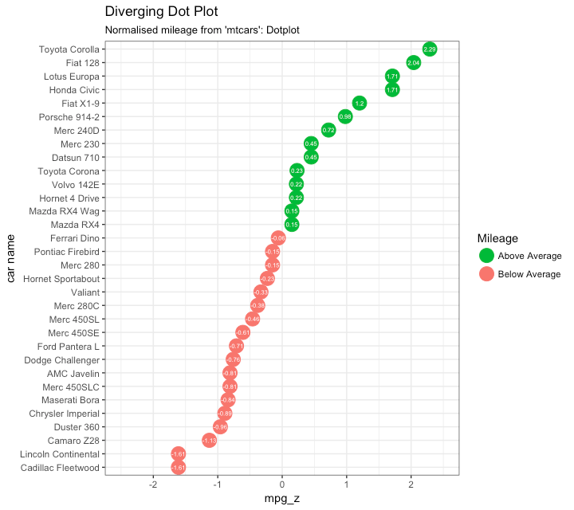

Standard deviation diagram for a normally distributed data (source: [Wikipedia](https://en.wikipedia.org/wiki/Standard_error))

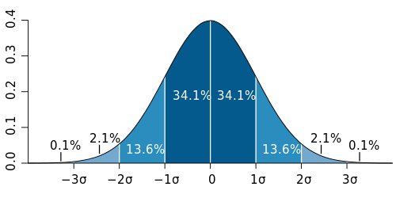

### Confidence Interval

Main question: based on a given sample, what can we infer about the population?
If we have just a single sample, perhaps the best estimate of the average value would be the sample mean, usually denoted as $\bar{x}$ (pronounced as x_bar). If we take more samples, their mean would differ a little (or a lot). So, the question is, how uncertain we are of that point estimate. For example, we would like to be 95% sure that the mean of any taken sample will be within certain interval.
For a known standard deviation,
$$CI_{95\%} = \bar{x} \pm 1.96*\frac{sd}{\sqrt{n}}$$
given that the values in X are randomly distributed and independent of each other.

Thus, we can say that there is only a 5% chance that the **confidence interval** excludes the mean of the population.  
CI can be shown at different confidence levels, for example 90%, 95% and 99%. The coefficients for the calcuating CI are the following: 1.645 for 90% CI, 1.96 for 95%, 2.326 for 98% CI, 2.576 for 99% CI.

```r
unique(mtcars$vs) # vs is either V-engine or Straight-engine
mtcars %>%
  group_by(vs) %>%
  summarise(mean.mpg = mean(mpg, na.rm = TRUE),
            sd.mpg = sd(mpg, na.rm = TRUE),
            n.mpg = n()) %>%
  mutate(se.mpg = sd.mpg / sqrt(n.mpg),
         lower.ci.mpg = mean.mpg - qt(1 - (0.05 / 2), n.mpg - 1) * se.mpg,
         upper.ci.mpg = mean.mpg + qt(1 - (0.05 / 2), n.mpg - 1) * se.mpg)
```